# Employee Data Analysis

Samson. O

2026-04-13

# Project Overview

This project analyzes employee productivity, salary distribution, and project workload using **R** and **ggplot2**.  
The analysis includes data transformation, summary statistics, and visualization to uncover patterns in employee performance across departments.

## Environment Setup

This analysis uses the following R packages:

- **dplyr** for data manipulation
- **tidyr** for data reshaping
- **ggplot2** for data visualization
- **knitr** for table formatting
- **ggrepel** for text labels readability

```r
library(dplyr)
library(tidyr)
library(ggplot2)
library(knitr)
library(ggrepel)
```

### Creating dataset

```r
employee_data <- data.frame(
  employee = c("John", "Mary", "David", "Sarah", "Daniel",
               "Grace", "Michael", "Linda", "James", "Sophia"),
  department = c("IT", "HR", "IT", "Finance", "IT",
                 "HR", "Finance", "IT", "HR", "Finance"),
  experience = c(3, 5, 2, 6, 4,
                 7, 3, 5, 4, 6),
  salary = c(4500, 5200, 4000, 6000, 4800,
             6500, 4700, 5300, 5000, 6200),
  project = c(5, 6, 3, 7, 4,
              8, 5, 6, 5, 7),
  hoursworked = c(160, 170, 150, 180, 165,
                  175, 160, 172, 168, 178)
    )

kable(head(employee_data, 10),
      caption = "Sample of Employee Data",
      col.names = c("Employee", "Department", "Experience", "Salary", "Project", "HoursWorked"))
```

Sample of Employee Data

| Employee | Department | Experience | Salary | Project | HoursWorked |
| --- | --- | --- | --- | --- | --- |
| John | IT | 3 | 4500 | 5 | 160 |
| Mary | HR | 5 | 5200 | 6 | 170 |
| David | IT | 2 | 4000 | 3 | 150 |
| Sarah | Finance | 6 | 6000 | 7 | 180 |
| Daniel | IT | 4 | 4800 | 4 | 165 |
| Grace | HR | 7 | 6500 | 8 | 175 |
| Michael | Finance | 3 | 4700 | 5 | 160 |
| Linda | IT | 5 | 5300 | 6 | 172 |
| James | HR | 4 | 5000 | 5 | 168 |
| Sophia | Finance | 6 | 6200 | 7 | 178 |

### Transformation of Data

```r
employee_data_clean <- employee_data %>%
  mutate(salary_per_project = salary / project,
         productivity = project / hoursworked,
         performance = ifelse(project >= 7, "Excellent",
                              ifelse(project >= 5 & project <= 6, "Good",
                                     "Average")))


kable(employee_data_clean %>%
        select(employee, department, salary_per_project, productivity, performance),
      caption = "Transformed Employee Data",
      col.names = c("Employee", "Department", "Salary/Project", "Productivity", "Performance"))
```

Transformed Employee Data

| Employee | Department | Salary/Project | Productivity | Performance |
| --- | --- | --- | --- | --- |
| John | IT | 900.0000 | 0.0312500 | Good |
| Mary | HR | 866.6667 | 0.0352941 | Good |
| David | IT | 1333.3333 | 0.0200000 | Average |
| Sarah | Finance | 857.1429 | 0.0388889 | Excellent |
| Daniel | IT | 1200.0000 | 0.0242424 | Average |
| Grace | HR | 812.5000 | 0.0457143 | Excellent |
| Michael | Finance | 940.0000 | 0.0312500 | Good |
| Linda | IT | 883.3333 | 0.0348837 | Good |
| James | HR | 1000.0000 | 0.0297619 | Good |
| Sophia | Finance | 885.7143 | 0.0393258 | Excellent |

### Summary Analysis

The following analysis calculates department-level statistics including average salary, maximum salary, employee count, and productivity.

```r
summary <- employee_data_clean %>%
  group_by(department) %>%
  summarise(
    avg_salary = mean(salary),
    max_salary = max(salary),
    min_salary = min(salary),
    total_project = sum(project),
    employeecount = n(),
    avg_productivity = mean(productivity)
  )

kable(summary,
      caption = "Department Summary Statistics",
      col.names = c("Department", "Avg Salary", "Max Salary",
                    "Min Salary", "Total Projects", "Headcount", "Avg Productivity"),
      digits = 4)
```

Department Summary Statistics

| Department | Avg Salary | Max Salary | Min Salary | Total Projects | Headcount | Avg Productivity |
| --- | --- | --- | --- | --- | --- | --- |
| Finance | 5633.333 | 6200 | 4700 | 19 | 3 | 0.0365 |
| HR | 5566.667 | 6500 | 5000 | 19 | 3 | 0.0369 |
| IT | 4650.000 | 5300 | 4000 | 18 | 4 | 0.0276 |

## Visualisation

### Average Salary by Department

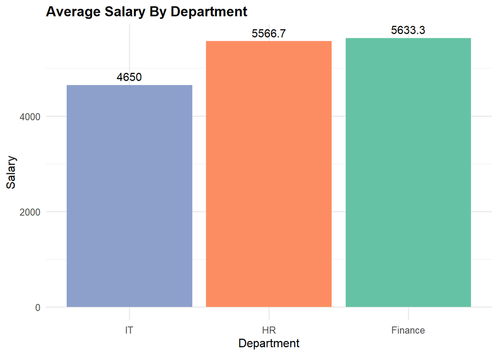

```r
ggplot(data = summary, aes(x = reorder(department, avg_salary),
                             y = avg_salary, fill = department)) +
   geom_col(show.legend = FALSE) +
    geom_text(aes(label = round(avg_salary, 1)), vjust = -0.5, size = 4) +
    scale_fill_brewer(palette = "Set2") +
    labs(
      title = "Average Salary By Department",
      x = "Department",
      y = "Salary"
    ) +
    theme_minimal(base_size = 12) +
    theme(
      plot.title = element_text(face = "bold", size = 14)
    )
```

### Project Per Employee

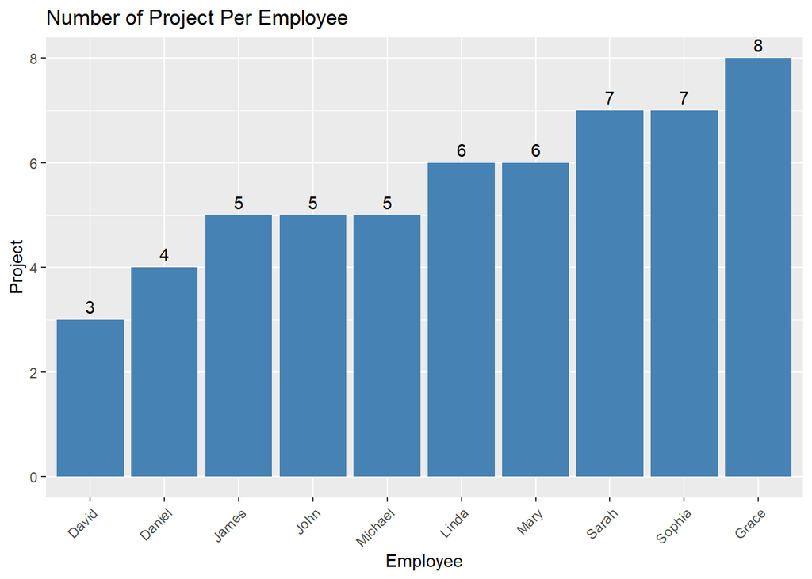

```r
 ggplot(data = employee_data_clean, aes(x = reorder(employee, project),
                                          y = project)) +
     geom_col(fill = "steelblue") +
     geom_text(aes(label = project), vjust = -0.5) +
     labs(
       title = "Number of Project Per Employee",
       x = "Employee",
       y = "Project"
     ) +
     theme(axis.text.x = element_text(angle = 45, hjust = 1))
```

### Salary vs Experience

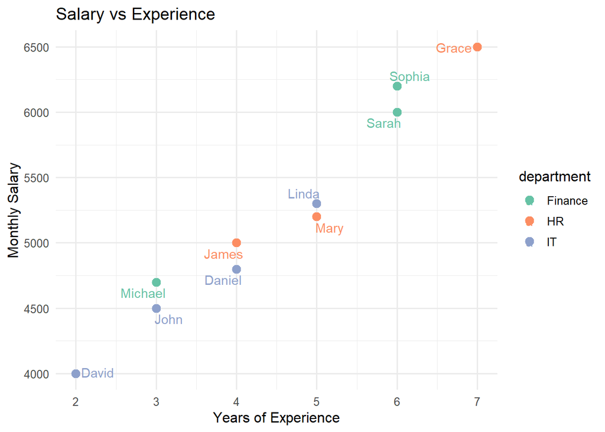

```r
  ggplot(data = employee_data_clean,
          mapping = aes(x = experience,
                        y = salary, color = department)) +
     geom_point(size = 3) +
     geom_text_repel(aes(label = employee)) +
     scale_color_brewer(palette = "Set2") +
     labs(
       title = "Salary vs Experience",
       x = "Years of Experience",
       y = "Monthly Salary"
     ) +
     theme_minimal(base_size = 12)
```

### Project vs WorkHours

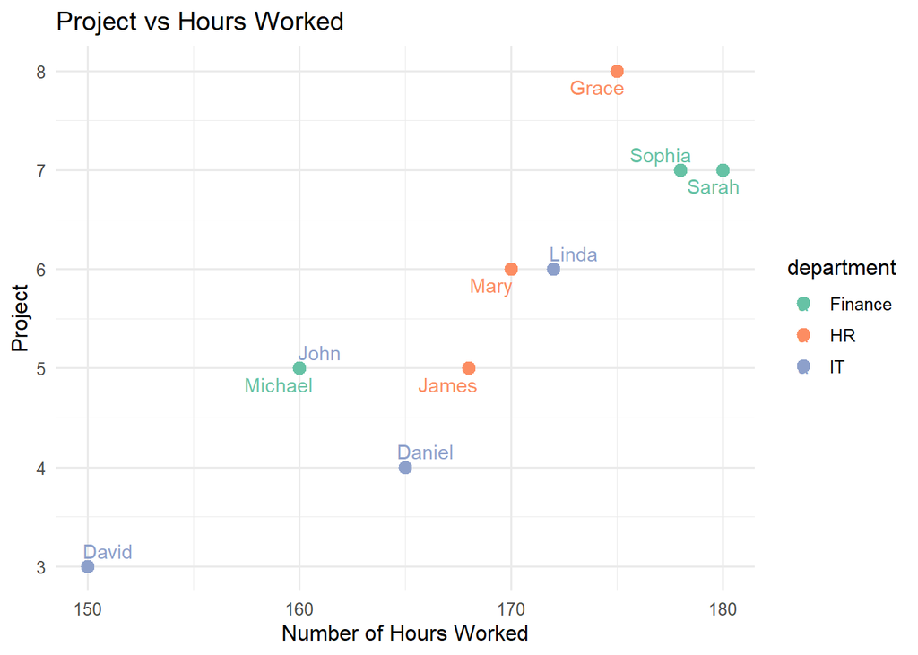

```r
 ggplot(data = employee_data_clean, mapping = aes(x = hoursworked, y = project, color = department)) +
     geom_point(size = 3) +
     geom_text_repel(aes(label = employee)) +
     scale_color_brewer(palette = "Set2") +
     labs(
       title = "Project vs Hours Worked",
       x = "Number of Hours Worked",
       y = "Project"
     ) +
     theme_minimal(base_size = 12)
```